# Title: Haberman's Survival Data

## Data Description:

The Haberman's survival dataset contains cases from a study that was conducted between 1958 and 1970 at the University of Chicago's Billings Hospital on the survival of patients who had undergone surgery for breast cancer.

## Objective:

Our obective is to classify or predict the patient who are survived after the breast cancer surgery and from the persons who are dead after the breast cancer surgery.

**Number of Instances:** 306  
**Number of Attributes:** 4 (including the class attribute)

## Attribute Information:

1) Age of patient at time of operation (numerical)  
2) Patient's year of operation (year - 1900, numerical)  
3) Number of positive axillary nodes detected (numerical)  
4) Survival status (class attribute)

> 1 = the patient survived 5 years or longer  
> 2 = the patient died within 5 year  
> Missing Attribute Values: None

```python
# Importing libraries
import pandas as pd  # Used for cleaning, transforming, manipulating and analyzing data
import numpy as np  # performing array operation as well as any numerical operation
import matplotlib.pyplot as plt  # Used for multi-platform data visualization
import seaborn as sns # Used for same as matplotlib but It provides a high-level interface for drawing attractive and informative statistical graphics.
```

```python
# To load/read data from CSV file using pandas Alias
df = pd.read_csv("datasets_474_966_haberman.csv")
df.head()
```

|  | 30 | 64 | 1 | 1.1 |
| --- | --- | --- | --- | --- |
| 0 | 30 | 62 | 3 | 1 |
| 1 | 30 | 65 | 0 | 1 |
| 2 | 31 | 59 | 2 | 1 |
| 3 | 31 | 65 | 4 | 1 |
| 4 | 33 | 58 | 10 | 1 |

```python
# In our dataset there has no column name so now Renaming column name for better understanding
df = pd.read_csv("datasets_474_966_haberman.csv",header=None)

# Making column list with respect to attribute information
column = ['age', 'operation_year', 'positive_lymph_nodes', 'survival_status']
df.columns = column

# It gives you a top 5 rows from our dataframe
df.head()
```

|  | age | operation_year | positive_lymph_nodes | survival_status |
| --- | --- | --- | --- | --- |
| 0 | 30 | 64 | 1 | 1 |
| 1 | 30 | 62 | 3 | 1 |
| 2 | 30 | 65 | 0 | 1 |
| 3 | 31 | 59 | 2 | 1 |
| 4 | 31 | 65 | 4 | 1 |

```python
# For looking last five rows from our dataset
df.tail()
```

|  | age | operation_year | positive_lymph_nodes | survival_status |
| --- | --- | --- | --- | --- |
| 301 | 75 | 62 | 1 | 1 |
| 302 | 76 | 67 | 0 | 1 |
| 303 | 77 | 65 | 3 | 1 |
| 304 | 78 | 65 | 1 | 2 |
| 305 | 83 | 58 | 2 | 2 |

## Data Preparation

It is the process of cleaning and transforming raw data prior to processing and analysis. It is an important step prior to processing and often involves reformatting data, making corrections to data and the combining of data sets to enrich data

```python
# To know the summary of our data from this to know whether out dataset consist null value or not ? and also we can identify the datatype of out data.
df.info()
```

```
<class 'pandas.core.frame.DataFrame'>
RangeIndex: 306 entries, 0 to 305
Data columns (total 4 columns):
 #   Column                Non-Null Count  Dtype
---  ------                --------------  -----
 0   age                   306 non-null    int64
 1   operation_year        306 non-null    int64
 2   positive_lymph_nodes  306 non-null    int64
 3   survival_status       306 non-null    int64
dtypes: int64(4)
memory usage: 9.7 KB
```

#### Observation:

- In our dataset there are no missing values. So we not need to do data imputation.
- In out dataset the datatype of 'survival_status' column is integer. It has to be converted to categorical datatype. so the values of 'survival_status' column are not meanigful. Hence they are mapped to 'yes' (survived after 5 years) and 'no' (not survived after 5 years).

```python
# To know statistical summary of dataset
# Its gives us descriptive stats including: mean, median, max, min, std and count for a particular column in the data.
df.describe()
```

|  | age | operation_year | positive_lymph_nodes | survival_status |
| --- | --- | --- | --- | --- |
| count | 306.000000 | 306.000000 | 306.000000 | 306.000000 |
| mean | 52.457516 | 62.852941 | 4.026144 | 1.264706 |
| std | 10.803452 | 3.249405 | 7.189654 | 0.441899 |
| min | 30.000000 | 58.000000 | 0.000000 | 1.000000 |
| 25% | 44.000000 | 60.000000 | 0.000000 | 1.000000 |
| 50% | 52.000000 | 63.000000 | 1.000000 | 1.000000 |
| 75% | 60.750000 | 65.750000 | 4.000000 | 2.000000 |
| max | 83.000000 | 69.000000 | 52.000000 | 2.000000 |

```python
# Printing the unique values of the target column and our target column is the survival_status
print(df['survival_status'].unique())

print("-"*50)

# To know whether how many rows has 1 value and for 0 value
print(df['survival_status'].value_counts())
```

```
[1 2]
--------------------------------------------------
1    225
2     81
Name: survival_status, dtype: int64
```

```python
# To modify our target column values to be meaningful as categorical data.
# 1 = the patient survived 5 years or longer, 2 = the patient died within 5 year
df['survival_status'] = df['survival_status'].map({1:"yes", 2:"no"})
df['survival_status'] = df['survival_status'].astype('category')
print(df.head())
```

```
   age  operation_year  positive_lymph_nodes survival_status
0   30              64                     1             yes
1   30              62                     3             yes
2   30              65                     0             yes
3   31              59                     2             yes
4   31              65                     4             yes
```

### Summary:

```python
print("Number of rows and columns of our dataframe: " + str(df.shape))
print("Columns: " + ", ".join(df.columns))

print("-"*50)

print("Target variable distribution")
print(df.iloc[:,-1].value_counts())

print("-"*50)

print(df.iloc[:,-1].value_counts(normalize = True))
```

```
Number of rows and columns of our dataframe: (306, 4)
Columns: age, operation_year, positive_lymph_nodes, survival_status
--------------------------------------------------
Target variable distribution
yes    225
no      81
Name: survival_status, dtype: int64
--------------------------------------------------
yes    0.735294
no     0.264706
Name: survival_status, dtype: float64
```

#### Observation:

- Our dataset is imbalanced dataset because It consist of `73%` of values are `YES` and the `26%` of values are `NO`.

## Univariate Analysis:

Univariate analysis is the simplest form of analyzing data. “Uni” means “one”, so in other words your data has only one variable. It doesn’t deal with causes or relationships (unlike regression ) and it’s major purpose is to describe; It takes data, summarizes that data and finds patterns in the data.

- PDF (Probability Density Function)
- CDF (Cummulative Distributed Function)
- Box plot
- Violin Plot

### 1) PDF(Probability Density Function):

- It is describes the probability distribution of the continues random variable.

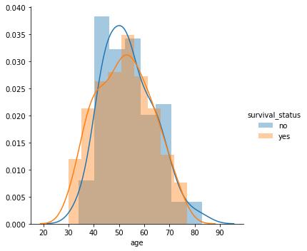

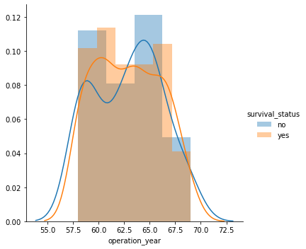

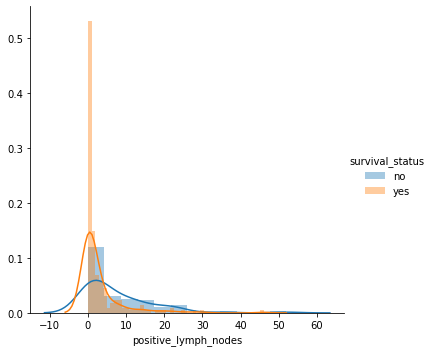

```python
import warnings
warnings.filterwarnings("ignore") # For removing warning when it showing result

for idx, feature in enumerate(list(df.columns)[:-1]):
    fg = sns.FacetGrid(df, hue='survival_status', size=5)
    fg.map(sns.distplot, feature).add_legend()
    plt.show()
```

#### Observations:

- Above all three plots the features are overlapping each other massively. But we can say probabily `58%` people survived who had `0-5` positive_lymph_nodes and `12%` died as well.

### 2) CDF (Cumulative Dencity Function):

- It is describing the distribution of random variables either it is continuous or discrete.

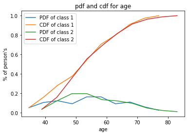

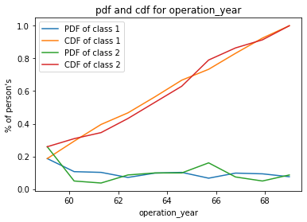

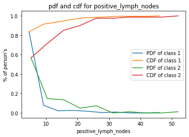

```python
for idx, feature in enumerate(list(df.columns)[:-1]):
    yes = df.loc[df["survival_status"] == "yes"]
    no = df.loc[df["survival_status"] == "no"]
    label = ["PDF of class 1", "CDF of class 1", "PDF of class 2", "CDF of class 2"]

    counts, bin_edges = np.histogram(yes[feature], bins=10, density = True)
    pdf = counts/(sum(counts))
    cdf = np.cumsum(pdf)

    plt.title("pdf and cdf for {}".format(feature))
    plt.xlabel("{}".format(feature))
    plt.ylabel("% of person's")
    plt.plot(bin_edges[1:], pdf)
    plt.plot(bin_edges[1:], cdf)

    counts, bin_edges = np.histogram(no[feature], bins=10, density = True)
    pdf = counts/(sum(counts))
    cdf = np.cumsum(pdf)
    plt.plot(bin_edges[1:], pdf)
    plt.plot(bin_edges[1:], cdf)
    plt.legend(label)

    plt.show()
```

#### Observations:

- Survived Patient : `15%` of the Patient's have less than or equal to age `37`.
- Not survived Patient : Patient's who has more than `46` auxillary_lymph_node.

### 3) Box Plot:

Boxplots are a standardized way of displaying the distribution of data based on a five number summary (“minimum”, first quartile (Q1), median, third quartile (Q3), and “maximum”).

- **median (Q2/50th Percentile):** the middle value of the dataset.
- **first quartile (Q1/25th Percentile):** the middle number between the smallest number (not the “minimum”) and the median of the dataset.
- **third quartile (Q3/75th Percentile):** the middle value between the median and the highest value (not the “maximum”) of the dataset.
- **interquartile range (IQR):** 25th to the 75th percentile.
- **maximum:** Q3 + 1.5*IQR
- **minimum:** Q1 -1.5*IQR

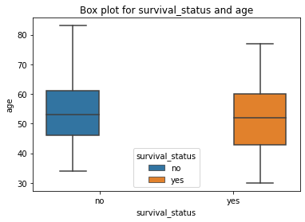

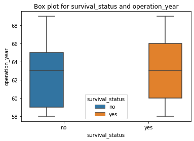

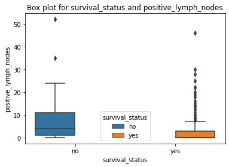

```python
for idx, feature in enumerate(list(df.columns)[:-1]):
    sns.boxplot(x = "survival_status", y = feature, hue = "survival_status", data = df).set_title("Box plot for survival_status and {}".format(feature))
    plt.show()
```

### 4) Violin Plot:

- Violin plot is the combination of box plot and probability density function.

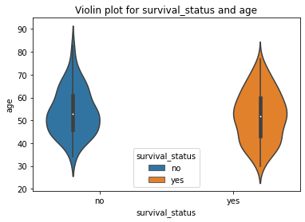

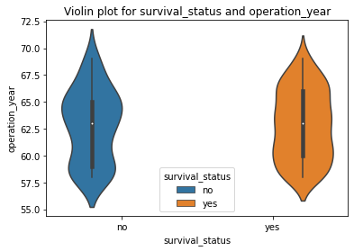

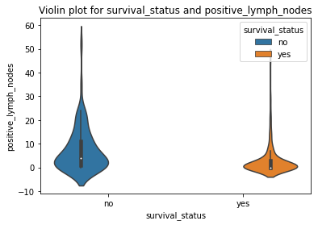

```python
for idx, feature in enumerate(list(df.columns)[:-1]):
    sns.violinplot( x='survival_status', y=feature, hue = "survival_status", data=df)
    plt.title("Violin plot for survival_status and {}".format(feature))
    plt.show()
```

#### Observations:

- The number of positive lymph nodes of the survivors is highly densed from 0 to 5. (PDF)
- Almost 80% of the patients have less than or equal to 5 positive lymph nodea. (CDF)
- The patients treated after 1966 have the slighlty higher chance to surive that the rest. The patients treated before 1959 have the slighlty lower chance to surive that the rest. (Box Plot and Violin Plot)

## Bivariate Analysis:

It is one of the simplest forms of quantitative analysis. It involves the analysis of two variables, for the purpose of determining the empirical relationship between them. Bivariate analysis can be helpful in testing simple hypotheses of association.

- Scatter Plot
- Pair Plot

### 1) Scatter Plot:

It is used to plot data points on a horizontal and a vertical axis in the attempt to show how much one variable is affected by another. Each row in the data table is represented by a marker whose position depends on its values in the columns set on the X and Y axes.

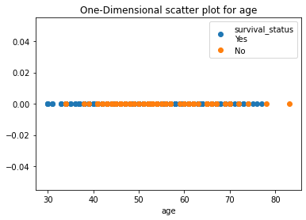

```python
# One Dimentional Scatter plot
yes = df.loc[df["survival_status"] == "yes"]
no = df.loc[df["survival_status"] == "no"]
plt.plot(yes["age"], np.zeros_like(yes["age"]), 'o', label = "survival_status\n" "Yes")
plt.plot(no["age"], np.zeros_like(no["age"]), 'o', label = "No")
plt.title("One-Dimensional scatter plot for age")
plt.xlabel("age")
plt.legend()
plt.show()
```

#### Observations:

- After looking at this plot we can easily count number of points that are there in age range who survived or not. so Many person died whose age was between 41-70.

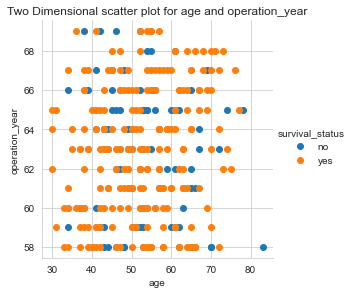

```python
# Two Dimensional ScatterPlot
sns.set_style("whitegrid")
sns.FacetGrid(df, hue = "survival_status", size = 4).map(plt.scatter, "age", "operation_year").add_legend()
plt.title("Two Dimensional scatter plot for age and operation_year")
plt.show()
```

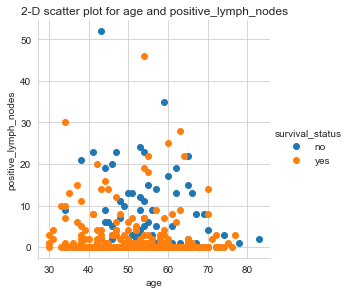

```python
# Two Dimensional ScatterPlot
sns.set_style("whitegrid")
sns.FacetGrid(df, hue = "survival_status", size = 4).map(plt.scatter, "age", "positive_lymph_nodes").add_legend()
plt.title("2-D scatter plot for age and positive_lymph_nodes")
plt.show()
```

#### Observations:

- In the above 2d scatter plot class label(i.e. a person died or survived) is not linearly seprable
- 0-5 positive_lymph_nodes person survived and died as well but the died ratio is less than survive ratio.

### 2) Pair Plot:

Pair Plots are a really simple (one-line-of-code simple!) way to visualize relationships between each variable. It produces a matrix of relationships between each variable in your data for an instant examination of our data. It can also be a great jumping off point for determining types of regression analysis to use.

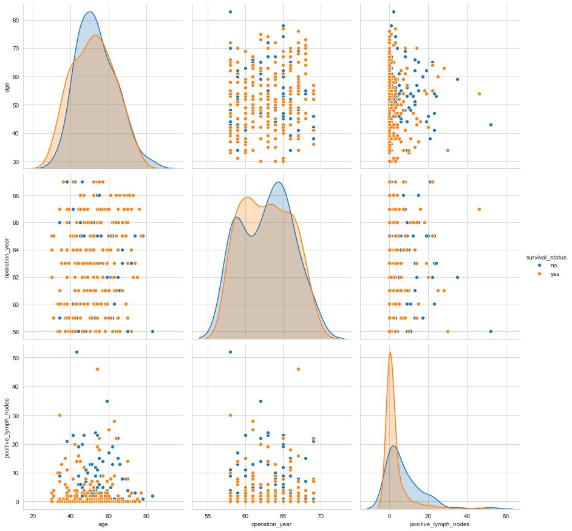

```python
sns.pairplot(df, hue='survival_status', size=4)
plt.show()
```

#### Observation:

- Useing scatter plot the data points between operation_year(year of treatment) and positive_lymph_nodes, we can see the better seperation between the two clases than other scatter plots..

### Conclusion:

- The dataset is imbalanced (Given dataset classes ratio is `73:26`), so we need to perform upsampling or downsampling (preferably upsampling as the dataset is already small one) while building a classifier model.
- The feature `positive_lymph_nodes` is the most informative feature with respect to the output level we are predicting here, and hence has most feature importance (or weightage) than the remaining ones.
- There is high chance of over-fitting to the data, given the small number of datapoints.
- The `positive_lymph_nodes` is giving some intution in the dataset.
- There are Patients who have 0 `positive_lymph_nodes` are more likely to survive.